# Concept of next word prediction application

Sukhovei Mikhail

05 09 2021

## Executive summary

This report presents the general concept of the algorithm for predicting the next word that will be entered by the user. For this purpose, we use the HC Corpus en_US dataset and the quanteda R package. The main idea of the algorithm is to predict the next word using ngrams (bigrams, trigrams and tetragrams). Having found all the ngrams in the corpus, we divide them into the left part (the predictor) and the right part (the predicted word), and then, using the matrix of coincidence frequencies, we can make a prediction for one, two or three words typed by the user.  
Data preparation pipeline consist of data loading, word tokens extraction, generating ngrams and generating co-occurance matrix.

## Data preparation

```r
paths.en_US <- c(
    file.path("data", "en_US", "en_US.blogs.txt"),
    file.path("data", "en_US", "en_US.news.txt"),
    file.path("data", "en_US", "en_US.twitter.txt")
)
```

### load data

At the data loading stage, we do not use all the data, because a small amount of data well represents the entire corpus. We don’t mix the data from blogs, news and twitter corpora for more detailed analysis.

```r
files.en_US = list()
for (path in paths.en_US) {
    files.en_US[[path]] <- readLines(path, n=20000, encoding = "UTF-8")
}
```

### extract word tokens

For tokenization, we do not need any punctuation marks, numbers and URLs. As we will see later, we need a more thorough stage of data cleaning.

```r
tokens.en_US = list()
for (path in paths.en_US) {
    file <- files.en_US[[path]]

    tokens.en_US[[path]] <- tokens_tolower(tokens(
        file,
        what = "word",
        remove_punct = TRUE,
        remove_symbols = TRUE,
        remove_numbers = TRUE,
        remove_url = TRUE,
        remove_separators = TRUE,
        split_hyphens = FALSE,
        include_docvars = TRUE,  # not sure
        padding = FALSE
    ))
}
```

### generate ngrams

In order to predict the next word from one word entered by the user, we need to generate all possible digrams. For more accurate prediction, we will also use trigrams and tetragrams, but to use them, the user must enter two and three words.

```r
digms <- list()
for (path in paths.en_US) {
    digms[[path]] <- tokens_ngrams(tokens.en_US[[path]], n = 2)
}

trigms <- list()
for (path in paths.en_US) {
    trigms[[path]] <- tokens_ngrams(tokens.en_US[[path]], n = 3)
}

tetragms <- list()
for (path in paths.en_US) {
    tetragms[[path]] <- tokens_ngrams(tokens.en_US[[path]], n = 4)
}
```

### generate co-occurance matrix

The co-occurance matrix contains the frequency of matches of (n-1)grams with the last word.

For prediction we split all ngrams in corpora to (n-1)grams and predicted words.

```r
get.fcm <- function(ngms) {
    # https://github.com/quanteda/quanteda/issues/1413

    ngms_lst <- as.list(ngms)
    ngms_unlst <- unlist(ngms_lst)

    ngms_blank_sep <- stringi::stri_replace_last_fixed(ngms_unlst, "_", " ")

    tk2_lst <- tokens(ngms_blank_sep)

    fcm(tk2_lst, "window", window = 1, ordered = TRUE, tri = FALSE)
}
```

```r
fcm_digms <- list()
for (path in paths.en_US) {
    fcm_digms[[path]] <- get.fcm(digms[[path]])
}

fcm_trigms <- list()
for (path in paths.en_US) {
    fcm_trigms[[path]] <- get.fcm(trigms[[path]])
}

fcm_tetragms <- list()
for (path in paths.en_US) {
    fcm_tetragms[[path]] <- get.fcm(tetragms[[path]])
}
```

#### get top-10 next words by (n-1)gram

```r
get.top10.next.words <- function(fcm, ngram) {
    if (ngram %in% rownames(fcm)) {
        top10 <- topfeatures(fcm[ngram, ], n = 10)
        top10 <- data.frame(top10)
        names(top10) <- c("freq")
        top10
    } else {
        NULL
    }
}
```

#### get top-10 predecessor (n-1)grams by word

```r
get.top10.predecessor.words <- function(fcm, word) {
    if (word %in% rownames(fcm)) {
        frame <- convert(fcm[, word], to = "data.frame")
        top10 <- head(frame[order(-frame[word], frame["doc_id"]), ], 10)
        rownames(top10) <- unlist(top10["doc_id"])
        top10["doc_id"] <- NULL
        names(top10) <- c("freq")
        top10
    } else {
        NULL
    }
}
```

## EDA

```r
print(paths.en_US)
```

```
## [1] "data/en_US/en_US.blogs.txt"   "data/en_US/en_US.news.txt"
## [3] "data/en_US/en_US.twitter.txt"
```

### number of tokens

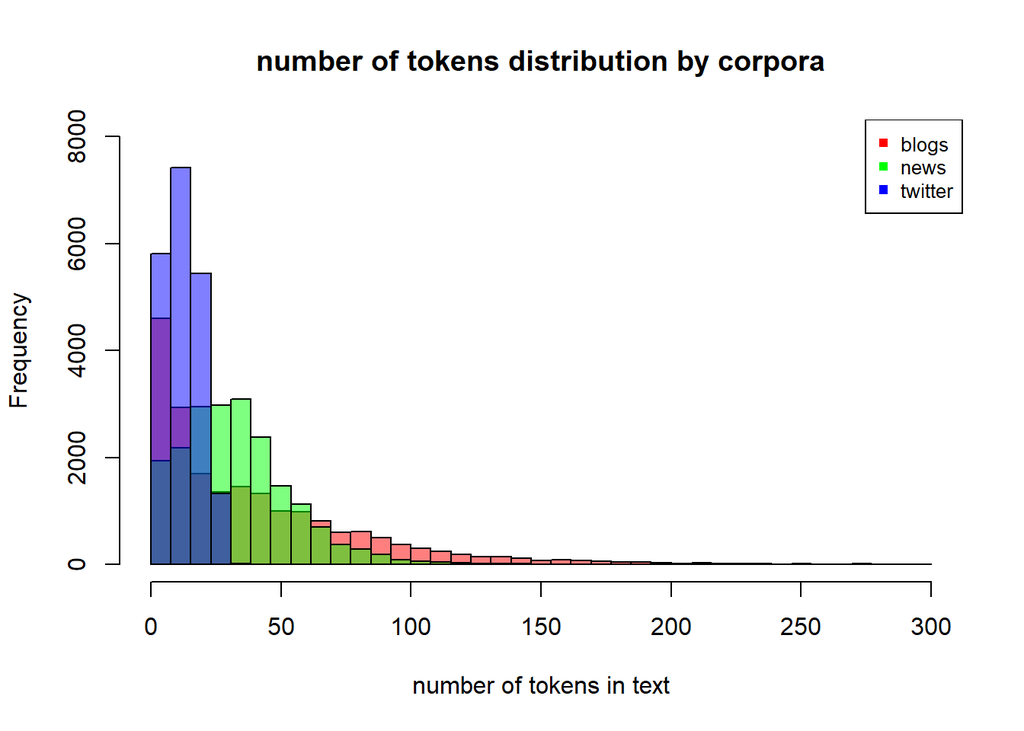

From histogram we can see that

- twitter texts significantly shorter than blogs and news
- news texts slightly shorter than blogs

### Zipf’s word frequency law

The frequency distribution of words approximately follows a simple mathematical form known as Zipf’s law: the $r$th most frequent word has a frequency $f(r)$ that scales according to

$$\begin{equation}
f(r) \propto \frac{1}{r^{\alpha}}
\end{equation}$$

for $\alpha \approx 1$ (Zipf, 1936, 1949).

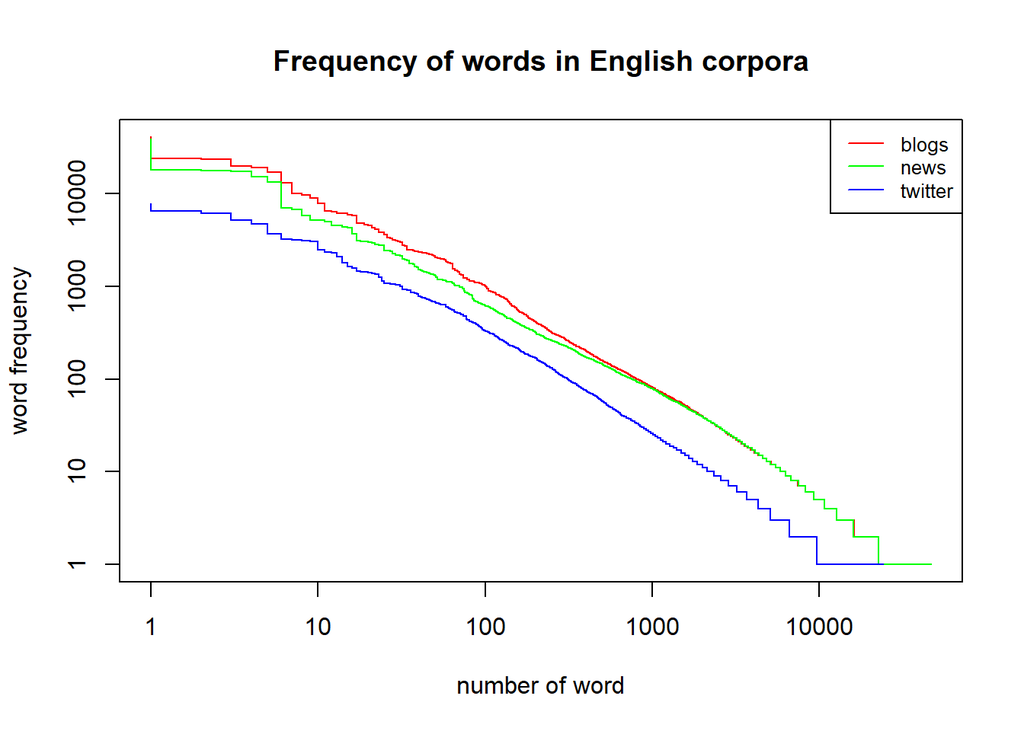

From this figure, we can see that

- all the corpora contain texts written in natural language
- blogs and news corpora have almost the same vocabulary size
- twitter vocabulary size is almost two times smaller than blogs and news

### most frequent left part (predictor)

#### digrams

```r
for (path in paths.en_US) {
    print(path)
    print(head(sort(rowSums(fcm_digms[[path]]), decreasing = TRUE)))
}
```

```
## [1] "data/en_US/en_US.blogs.txt"
##   the   and    to     a    of     i
## 41134 24159 23314 19759 19202 16905
## [1] "data/en_US/en_US.news.txt"
##   the   and    to     a    of    in
## 39021 17889 17806 17400 15273 13106
## [1] "data/en_US/en_US.twitter.txt"
##  the   to    i    a  you  and
## 7808 6474 6161 5173 4350 3650
```

#### trigrams

```r
for (path in paths.en_US) {
    print(path)
    print(head(sort(rowSums(fcm_trigms[[path]]), decreasing = TRUE)))
}
```

```
## [1] "data/en_US/en_US.blogs.txt"
##  of_the  in_the  to_the  on_the   to_be and_the
##    4166    3497    1924    1636    1489    1336
## [1] "data/en_US/en_US.news.txt"
##  of_the  in_the  to_the  on_the for_the  at_the
##    3586    3572    1628    1409    1357    1176
## [1] "data/en_US/en_US.twitter.txt"
##     in_the    for_the     of_the      to_be     on_the thanks_for
##        671        619        474        409        380        373
```

#### tetragrams

```r
for (path in paths.en_US) {
    print(path)
    print(head(sort(rowSums(fcm_tetragms[[path]]), decreasing = TRUE)))
}
```

```
## [1] "data/en_US/en_US.blogs.txt"
##  one_of_the    a_lot_of  as_well_as  the_end_of some_of_the  out_of_the
##         338         304         152         150         144         140
## [1] "data/en_US/en_US.news.txt"
##       one_of_the         a_lot_of       as_well_as according_to_the
##              274              220              128              119
##       the_end_of       out_of_the
##              106              102
## [1] "data/en_US/en_US.twitter.txt"
##     thanks_for_the                  ' looking_forward_to      thank_you_for
##                213                136                 71                 71
##          i_want_to        going_to_be
##                 69                 65
```

We can see that

- blogs and news corpora give almost the same top-6 left part of ngrams
- twitter is significantly differ from blogs and news text

### most frequent right part (predicted word)

```r
for (path in paths.en_US) {
    print(path)
    print(topfeatures(fcm_digms[[path]]))
}
```

```
## [1] "data/en_US/en_US.blogs.txt"
##   the   and    to     a    of     i    in  that    is    it
## 39814 23728 23244 19483 19184 15259 12730  9925  9571  8613
## [1] "data/en_US/en_US.news.txt"
##   the    to   and     a    of    in   for  that    is    on
## 36502 17789 17725 17013 15287 12720  6892  6633  5768  5083
## [1] "data/en_US/en_US.twitter.txt"
##  the   to    a    i  you  and  for   in   of   is
## 7454 6522 5065 4379 4358 3549 3163 3060 3005 2997
```

## sample prediction

We can separately run three prediction models:

- digrams model
- trigram model
- tetragram model

```r
get.top10.next.words(fcm_digms[[paths.en_US[1]]], "the")
```

```
##       freq
## first  510
## same   490
## world  341
## time   318
## other  312
## way    303
## most   293
## best   271
## end    238
## last   228
```

```r
get.top10.next.words(fcm_trigms[[paths.en_US[1]]], "of_the")
```

```
##        freq
## most     60
## world    46
## year     46
## time     45
## first    40
## best     37
## day      33
## other    28
## things   26
## way      24
```

```r
get.top10.next.words(fcm_tetragms[[paths.en_US[1]]], "one_of_the")
```

```
##         freq
## most      39
## best      22
## things    15
## first     11
## many       8
## biggest    8
## few        7
## main       7
## great      6
## more       5
```

We see that the prediction of the tetragram model is more confident. Therefore, for forecasting, we need to first try to find the next word of the tetragram model, then the trigram model, and finally the diagram.

## algorithm concept

Pseudocode of shinyapp

```
user_input <- get()
user_tokens <- tokens(user_input)
length_tokens <- length(user_tokens)

if (length(user_input) >= 3) {
    next_word <- tetragram(user_tokens[length_tokens-2:length_tokens])
    if (is.null(next_word)) {
        next_word <- trigram(user_tokens[length_tokens-1:length_tokens])
        if (is.null(next_word)) {
            next_word <- digram(user_tokens[length_tokens])
        }
    }
} else if (length(user_input) >= 2) {
    next_word <- trigram(user_tokens[length_tokens-1:length_tokens])
    if (is.null(next_word)) {
        next_word <- digram(user_tokens[length_tokens])
    }
} else if (length(user_input) >= 1) {
    next_word <- digram(user_tokens[length_tokens])
} else {
    next_word <- NULL
}

set(next_word)
```

## Quiz predictions

- The guy in front of me just bought a pound of bacon, a bouquet, and a case of

```r
for (i in 1:3) {
    print(get.top10.next.words(fcm_tetragms[[paths.en_US[i]]], "a_case_of"))
}
```

```
##                       freq
## the                      1
## argument                 1
## underway                 1
## in_the_years             0
## thereafter               0
## the_years_thereafter     0
## most                     0
## years_thereafter_most    0
## of                       0
## thereafter_most_of       0
##                   freq
## trying               1
## international        1
## jan                  1
## double-dipping       1
## he_wasn't_home       0
## alone                0
## wasn't_home_alone    0
## apparently           0
## the_st_louis         0
## plant                0
##                freq
## red               1
## how_are_you       0
## btw               0
## are_you_btw       0
## thanks            0
## you_btw_thanks    0
## for               0
## btw_thanks_for    0
## the               0
## thanks_for_the    0
```

Possible improvements:

- more accurate data cleaning (reducing co-occurance matrix will give higher performance)
- since we need to recommend only one possible next word we need only ngrams with highest frequency therefore we can transform (n x n) co-occurance matrix to vector of length n with only maximal frequency predictions
- since blogs and news corpora is similar we can use, for example, only blogs
- since twitter corpus contains less tokens we need to take more texts from it

## Referencies

Zipf, G. (1936). The Psychobiology of Language. London: Routledge.  
Zipf, G. (1949). Human Behavior and the Principle of Least Effort. New York: Addison-Wesley.